# Multipale Rehression

Krishna Kumar Shrestha

2020-11-24

# Excersis 21.1

**In the MASS package, you’ll find the data frame cats, which provides data on sex, body weight (in kilograms), and heart weight (in grams) for 144 household cats (see Venables and Ripley, 2002, for further details); you can read the documentation with a call to ?cats. Load the MASS package with a call to library(“MASS”), and access the object directly by entering cats at the console prompt.**

1. Plot heart weight on the vertical axis and body weight on the horizontal axis, using different colors or point characters to distinguish between male and female cats. Annotate your plot with a legend and appropriate axis labels.

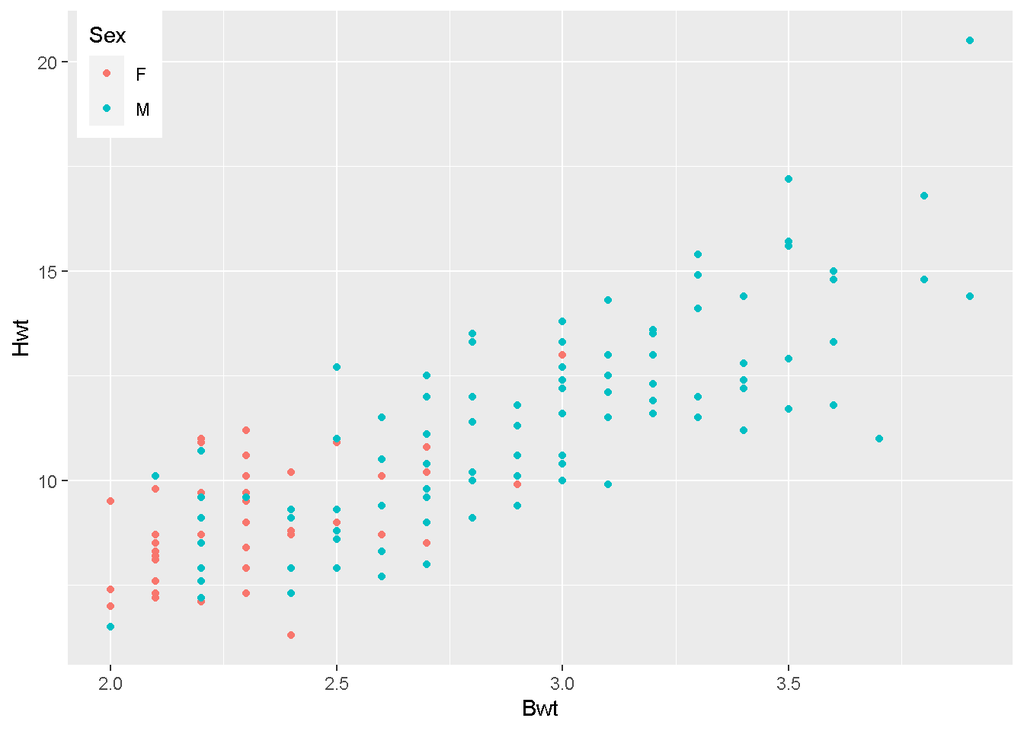

```r
data("cats")
cats %>%
  ggplot()+
  aes(x=Bwt,y=Hwt,col=Sex)+
  geom_point()+
  theme(
    legend.position = c(0.01,1),
    legend.justification = c("left", "top"),
    legend.box.just = "right",
    legend.margin = margin(6, 6, 6, 6)
    )
```

2. Fit a least-squares multiple linear regression model using heart weight as the response variable and the other two variables as predictors, and view a model summary.

```r
model1 <- lm(Hwt ~ Bwt + Sex, data = cats)
summary(model1)
```

```
##
## Call:
## lm(formula = Hwt ~ Bwt + Sex, data = cats)
##
## Residuals:
##     Min      1Q  Median      3Q     Max
## -3.5833 -0.9700 -0.0948  1.0432  5.1016
##
## Coefficients:
##             Estimate Std. Error t value Pr(>|t|)
## (Intercept)  -0.4149     0.7273  -0.571    0.569
## Bwt           4.0758     0.2948  13.826   <2e-16 ***
## SexM         -0.0821     0.3040  -0.270    0.788
## ---
## Signif. codes:  0 '***' 0.001 '**' 0.01 '*' 0.05 '.' 0.1 ' ' 1
##
## Residual standard error: 1.457 on 141 degrees of freedom
## Multiple R-squared:  0.6468, Adjusted R-squared:  0.6418
## F-statistic: 129.1 on 2 and 141 DF,  p-value: < 2.2e-16
```

1. Write down the equation for the fitted model and interpret the estimated regression coefficients for body weight and sex. Are both statistically significant? What does this say about the relationship between the response and predictors?

> the Equation is: y = -0.4149 + 4.0758*Bwt - 0.0821*SexM

Ans:**From the summary table , we can see that p value of Bwt is less then 0.05 which means the variable is significant for the model where as the sex variable have p value more then 0.05, so the variable is insignificant for the model**

2. Report and interpret the coefficient of determination and the outcome of the omnibus F -test.

Ans:**The coefficient of determination is 0.6468. It means that 65% of the variation of the Hwt can be explained by the model.even if it includes a not statistical relevant predictor variable in the model.**

3. Tilman’s cat, Sigma, is a 3.4 kg female. Use your model to estimate her mean heart weight and provide a 95 percent prediction interval.

```r
newdata = data.frame(Bwt = (3.4), Sex = ("F"))
predict(model1,
        newdata,
        interval = "prediction")
```

```
##        fit      lwr      upr
## 1 13.44266 10.46904 16.41628
```

4. Use predict to superimpose continuous lines based on the fitted linear model on your plot from (a), one for male cats and one for female. What do you notice? Does this reflect the statistical significance (or lack thereof) of the parameter estimates?

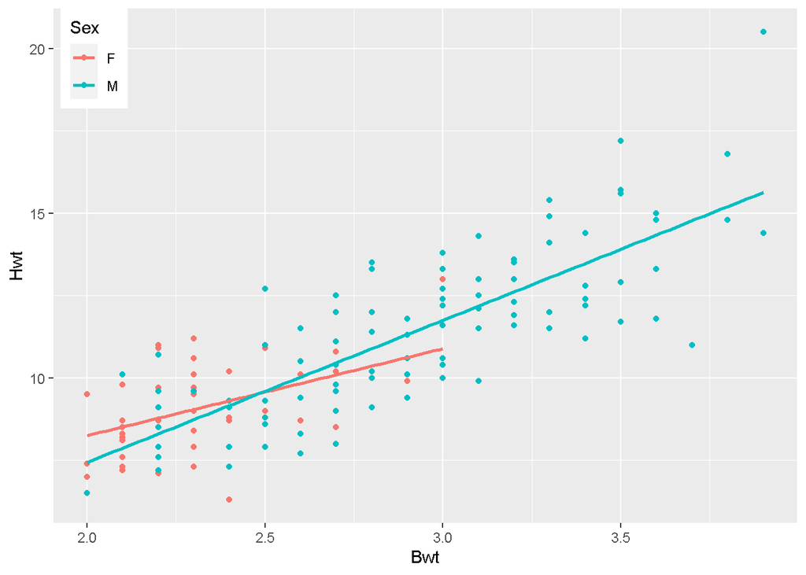

```r
cats %>%
  ggplot()+
  aes(x=Bwt,y=Hwt,col=Sex)+
  geom_point()+
  theme(
    legend.position = c(0.01,1),
    legend.justification = c("left", "top"),
    legend.box.just = "right",
    legend.margin = margin(6, 6, 6, 6)
    ) +
  geom_smooth(method = "lm",aes(col=Sex),se=0)
```

The boot package (Davison and Hinkley, 1997; Canty and Ripley, 2015) is another library of R code that’s included with the standard installation but isn’t automatically loaded. Load boot with a call to library(“boot”). You’ll find a data frame called nuclear, which contains data on the construction of nuclear power plants in the United States in the late 1960s (Cox and Snell, 1981). e. Access the documentation by entering ?nuclear at the prompt and examine the details of the variables. (Note there is a mistake for date, which provides the date that the construction permits were issued—it should read “measured in years since January 1 1900 to the nearest month.”) Use pairs to produce a quick scatterplot matrix of the data.

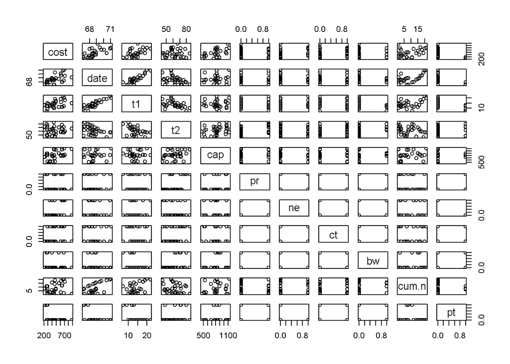

```r
library(boot)
data("nuclear")
pairs(nuclear)
```

6. One of the original objectives was to predict the cost of further construction of these power plants. Create a fit and summary of a linear regression model that aims to model cost by t1 and t2, two variables that describe different elapsed times associated with the application for and issue of various permits. Take note of the estimated regression coefficients and their significance in the fitted model.

```r
model2 <- lm(cost ~ t1 + t2, data = nuclear)
summary(model2)
```

```
##
## Call:
## lm(formula = cost ~ t1 + t2, data = nuclear)
##
## Residuals:
##     Min      1Q  Median      3Q     Max
## -273.17  -73.42  -13.40   69.31  360.61
##
## Coefficients:
##             Estimate Std. Error t value Pr(>|t|)
## (Intercept) -242.146    268.020  -0.903  0.37373
## t1            29.908      9.086   3.292  0.00262 **
## t2             4.689      2.945   1.592  0.12224
## ---
## Signif. codes:  0 '***' 0.001 '**' 0.01 '*' 0.05 '.' 0.1 ' ' 1
##
## Residual standard error: 150.1 on 29 degrees of freedom
## Multiple R-squared:  0.272,  Adjusted R-squared:  0.2218
## F-statistic: 5.418 on 2 and 29 DF,  p-value: 0.01001
```

7. Refit the model, but this time also include an effect for the date the construction permit was issued. Contrast the output for this new model against the previous one. What do you notice, and what does this information suggest about the relationships in the data with respect to these predictors?

```r
model3 <- lm(cost ~ t1 + t2 + date, data = nuclear)
summary(model3)
```

```
##
## Call:
## lm(formula = cost ~ t1 + t2 + date, data = nuclear)
##
## Residuals:
##     Min      1Q  Median      3Q     Max
## -208.63  -90.74  -12.07   59.78  324.19
##
## Coefficients:
##              Estimate Std. Error t value Pr(>|t|)
## (Intercept) -9232.833   2974.432  -3.104  0.00434 **
## t1             -5.918     14.281  -0.414  0.68176
## t2              4.639      2.601   1.784  0.08535 .
## date          138.324     45.617   3.032  0.00519 **
## ---
## Signif. codes:  0 '***' 0.001 '**' 0.01 '*' 0.05 '.' 0.1 ' ' 1
##
## Residual standard error: 132.5 on 28 degrees of freedom
## Multiple R-squared:  0.452,  Adjusted R-squared:  0.3933
## F-statistic: 7.698 on 3 and 28 DF,  p-value: 0.000667
```

8. Fit a third model for power plant cost, using the predictors for “date of permit issue,” “power plant capacity,” and the binary variable describing whether the plant was sited in the northeastern United States. Write down the fitted model equation and provide 95 percent confidence intervals for each estimated coefficient.

```r
model4 <- lm(cost ~ date + cap + ne, data = nuclear)
summary(model4)
```

```
##
## Call:
## lm(formula = cost ~ date + cap + ne, data = nuclear)
##
## Residuals:
##      Min       1Q   Median       3Q      Max
## -154.966  -68.202   -3.614   45.919  285.014
##
## Coefficients:
##               Estimate Std. Error t value Pr(>|t|)
## (Intercept) -6.458e+03  1.216e+03  -5.310 1.19e-05 ***
## date         9.544e+01  1.773e+01   5.382 9.77e-06 ***
## cap          4.157e-01  9.463e-02   4.393 0.000145 ***
## ne           1.261e+02  4.092e+01   3.083 0.004575 **
## ---
## Signif. codes:  0 '***' 0.001 '**' 0.01 '*' 0.05 '.' 0.1 ' ' 1
##
## Residual standard error: 99.74 on 28 degrees of freedom
## Multiple R-squared:  0.6895, Adjusted R-squared:  0.6562
## F-statistic: 20.73 on 3 and 28 DF,  p-value: 2.827e-07
```

```r
#Equation is: -6458.3889006 +95.4385587*date + 0.4157157*cap + 126.1287688*ne
confint(model4)
```

```
##                     2.5 %        97.5 %
## (Intercept) -8949.8032112 -3966.9745900
## date           59.1134640   131.7636535
## cap             0.2218791     0.6095524
## ne             42.3145363   209.9430014
```

The following table gives an excerpt of a historical data set compiled between 1961 and 1973. It concerns the annual murder rate in Detroit, Michigan; the data were originally presented and analyzed by Fisher (1976) and are reproduced here from Harraway (1995). In the data set you’ll find the number of murders, police officers, and gun licenses issued per 100,000 population, as well as the overall unemployment rate as a percentage of the overall population.

| Murders | Police | Unemployment | Guns |
| --- | --- | --- | --- |
| 8.60 | 260.35 | 11.0 | 178.15 |
| 8.90 | 269.80 | 7.0 | 156.41 |
| 8.52 | 272.04 | 5.2 | 198.02 |
| 8.89 | 272.96 | 4.3 | 222.10 |
| 13.07 | 272.51 | 3.5 | 301.92 |
| 14.57 | 261.26 | 3.2 | 391.22 |
| 21.36 | 268.89 | 4.1 | 665.56 |
| 28.03 | 295.99 | 3.9 | 1131.21 |
| 31.49 | 319.87 | 3.6 | 837.60 |
| 37.39 | 341.43 | 7.1 | 794.90 |
| 46.26 | 356.59 | 8.4 | 817.74 |
| 47.24 | 376.69 | 7.7 | 583.17 |
| 52.33 | 390.19 | 6.3 | 709.59 |

1. Create your own data frame in your R workspace and produce a scatterplot matrix. Which of the variables appears to be most strongly related to the murder rate?

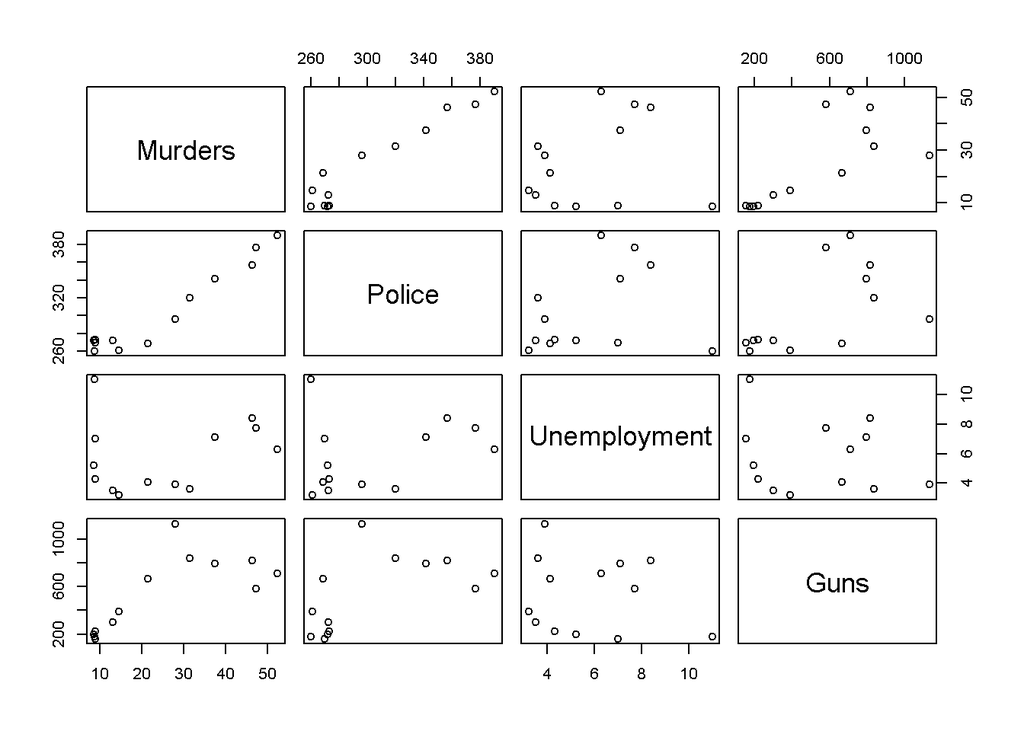

```r
pairs(security)
```

10. Fit a multiple linear regression model using the number of murders as the response and all other variables as predictors. Write down the model equation and interpret the coefficients. Is it reasonable to state that all relationships between the response and the predictors are causal?

```r
model5<-lm(Murders~Police+Unemployment+Guns,data=security)
summary(model5)
```

```
##
## Call:
## lm(formula = Murders ~ Police + Unemployment + Guns, data = security)
##
## Residuals:
##     Min      1Q  Median      3Q     Max
## -2.8453 -1.9445  0.2011  0.9195  4.6652
##
## Coefficients:
##                Estimate Std. Error t value Pr(>|t|)
## (Intercept)  -68.835174   5.868731 -11.729 9.35e-07 ***
## Police         0.280761   0.024686  11.373 1.21e-06 ***
## Unemployment   0.146590   0.408762   0.359   0.7281
## Guns           0.014176   0.003542   4.002   0.0031 **
## ---
## Signif. codes:  0 '***' 0.001 '**' 0.01 '*' 0.05 '.' 0.1 ' ' 1
##
## Residual standard error: 2.893 on 9 degrees of freedom
## Multiple R-squared:  0.9766, Adjusted R-squared:  0.9688
## F-statistic: 125.3 on 3 and 9 DF,  p-value: 1.171e-07
```

```r
#It is not reasonable to state that all relationshipps between response and
#predictors are casual. We can see that Guns also presents a strong statistical
# evidence of relationship with murders.
```

11. Identify the amount of variation in the response attributed to the joint effect of the three explanatory variables. Then refit the model excluding the predictor associated with the largest (in other words, “most nonsignificant”) p-value. Compare the new coefficient of determination with that of the previous model. Is there much difference?

```r
model<-lm(Murders~Police+Guns,data=security)
summary(model)
```

```
##
## Call:
## lm(formula = Murders ~ Police + Guns, data = security)
##
## Residuals:
##     Min      1Q  Median      3Q     Max
## -2.9453 -2.1083  0.2744  0.9578  4.6368
##
## Coefficients:
##               Estimate Std. Error t value Pr(>|t|)
## (Intercept) -68.985033   5.592973 -12.334 2.26e-07 ***
## Police        0.284992   0.020717  13.756 8.01e-08 ***
## Guns          0.013638   0.003065   4.449  0.00124 **
## ---
## Signif. codes:  0 '***' 0.001 '**' 0.01 '*' 0.05 '.' 0.1 ' ' 1
##
## Residual standard error: 2.764 on 10 degrees of freedom
## Multiple R-squared:  0.9763, Adjusted R-squared:  0.9715
## F-statistic: 205.8 on 2 and 10 DF,  p-value: 7.501e-09
```

```r
#Removing the unemployment predictor variable there is a much better statistical
#relation between the predictors and the answer. But hte model keeps having a
#great prediction capability.
```

12. Use your model from (k) to predict the mean number of murders per 100,000 residents, with 300 police officers and 500 issued gun licenses. Compare this to the mean response if there were no gun licenses issued and provide 99 percent confidence intervals for both predictions.

```r
newdata = data.frame(Police = 300, Guns = c(500, 0))
predict.lm(
      model,
      newdata = newdata,
      interval = "confidence",
      level = 0.99
)
```

```
##        fit      lwr      upr
## 1 23.33141 20.88171 25.78112
## 2 16.51253 10.89978 22.12529
```

# Exercise 21.2

The following table presents data collected in one of Galileo’s famous “ball” experiments, in which he rolled a ball down a ramp of different heights and measured how far it traveled from the base of the ramp. For more on this and other interesting examples, look at “Teaching Statistics with Data of Historic Significance” by Dickey and Arnold (1995).

1. Create a data frame in R based on this table and plot the data points with distance on the y-axis.

```r
Galileu<-data.frame(Iniheight=c(1000,800,600,450,300,200,100),
                    Dist=c(573,534,495,451,395,337,257))

kableExtra::kable(Galileu)
```

| Iniheight | Dist |
| --- | --- |
| 1000 | 573 |
| 800 | 534 |
| 600 | 495 |
| 450 | 451 |
| 300 | 395 |
| 200 | 337 |
| 100 | 257 |

[figure not shown]

```r
Galileu %>%
  ggplot()+
  aes(x=Dist,y=Iniheight)+
  geom_point()+
  ggtitle("Distance Traveled Vs. Initial Height")+
  xlab("Initial Height")+
  ylab("Distance")
```

2. Galileo believed there was a quadratic relationship between initial height and the distance traveled.
3. Fit an order 2 polynomial in height, with distance as the response.

```r
m.2<-lm(Dist~Iniheight+I(Iniheight^2),data=Galileu)
summary(m.2)
```

```
##
## Call:
## lm(formula = Dist ~ Iniheight + I(Iniheight^2), data = Galileu)
##
## Residuals:
##       1       2       3       4       5       6       7
##   8.011 -12.130  -5.573   2.115  12.821   7.634 -12.878
##
## Coefficients:
##                  Estimate Std. Error t value Pr(>|t|)
## (Intercept)     2.037e+02  1.549e+01  13.154 0.000193 ***
## Iniheight       6.950e-01  6.914e-02  10.052 0.000551 ***
## I(Iniheight^2) -3.337e-04  6.171e-05  -5.408 0.005662 **
## ---
## Signif. codes:  0 '***' 0.001 '**' 0.01 '*' 0.05 '.' 0.1 ' ' 1
##
## Residual standard error: 12.6 on 4 degrees of freedom
## Multiple R-squared:  0.9916, Adjusted R-squared:  0.9874
## F-statistic: 235.9 on 2 and 4 DF,  p-value: 7.065e-05
```

2. Fit a cubic (order 3) and a quartic (order 4) model for these data. What do they tell you about the nature of the relationship?

```r
m.3<-lm(Dist~Iniheight+I(Iniheight^2)+I(Iniheight^3),data=Galileu)
summary(m.3)
```

```
##
## Call:
## lm(formula = Dist ~ Iniheight + I(Iniheight^2) + I(Iniheight^3),
##     data = Galileu)
##
## Residuals:
##       1       2       3       4       5       6       7
## -0.6526  1.7768  0.1060 -3.8552  1.9856  2.4273 -1.7880
##
## Coefficients:
##                  Estimate Std. Error t value Pr(>|t|)
## (Intercept)     1.626e+02  6.726e+00  24.176 0.000155 ***
## Iniheight       1.074e+00  5.305e-02  20.248 0.000263 ***
## I(Iniheight^2) -1.173e-03  1.118e-04 -10.493 0.001848 **
## I(Iniheight^3)  5.102e-07  6.727e-08   7.585 0.004754 **
## ---
## Signif. codes:  0 '***' 0.001 '**' 0.01 '*' 0.05 '.' 0.1 ' ' 1
##
## Residual standard error: 3.24 on 3 degrees of freedom
## Multiple R-squared:  0.9996, Adjusted R-squared:  0.9992
## F-statistic:  2400 on 3 and 3 DF,  p-value: 1.443e-05
```

```r
m.4<-lm(Dist~Iniheight+I(Iniheight^2)+I(Iniheight^3)+I(Iniheight^4),
             data=Galileu)
summary(m.4)
```

```
##
## Call:
## lm(formula = Dist ~ Iniheight + I(Iniheight^2) + I(Iniheight^3) +
##     I(Iniheight^4), data = Galileu)
##
## Residuals:
##       1       2       3       4       5       6       7
##  0.1361 -0.7553  1.9752 -2.1722  0.7122  0.3645 -0.2604
##
## Coefficients:
##                  Estimate Std. Error t value Pr(>|t|)
## (Intercept)     1.490e+02  8.001e+00  18.619  0.00287 **
## Iniheight       1.254e+00  9.361e-02  13.395  0.00553 **
## I(Iniheight^2) -1.853e-03  3.347e-04  -5.535  0.03112 *
## I(Iniheight^3)  1.460e-06  4.577e-07   3.190  0.08581 .
## I(Iniheight^4) -4.372e-10  2.096e-10  -2.086  0.17232
## ---
## Signif. codes:  0 '***' 0.001 '**' 0.01 '*' 0.05 '.' 0.1 ' ' 1
##
## Residual standard error: 2.227 on 2 degrees of freedom
## Multiple R-squared:  0.9999, Adjusted R-squared:  0.9996
## F-statistic:  3811 on 4 and 2 DF,  p-value: 0.0002624
```